# GSB5544_PA_1_2_intro_to_pandas

**First save a copy of this notebook in your Google drive.** Read this notebook from top to bottom and fill in the code as you go. Work together with your partner and discuss with other students in the class. Try to resolve any errors on your own first, but don't get stuck; ask for help!

For many of these questions, there are several ways to do it in Pandas. You only need to choose one that works. But you might want to experiment with multiple ways of doing the same thing to get practice working with Pandas.

## Titanic Data

1. Read in the Titanic data set. What seems to be the observational unit?

```python
import pandas as pd
```

```python
titanic_df = pd.read_csv('https://raw.githubusercontent.com/kevindavisross/data301/main/data/titanic.csv')
titanic_df.head()
```

|  | name | gender | age | class | embarked | country | ticketno | fare | survived | pclass | crew |
| --- | --- | --- | --- | --- | --- | --- | --- | --- | --- | --- | --- |
| 0 | Abbing, Mr. Anthony | male | 42.0 | 3rd | S | United States | 5547.0 | 7.11 | 0 | 3.0 | NaN |
| 1 | Abbott, Mr. Eugene Joseph | male | 13.0 | 3rd | S | United States | 2673.0 | 20.05 | 0 | 3.0 | NaN |
| 2 | Abbott, Mr. Rossmore Edward | male | 16.0 | 3rd | S | United States | 2673.0 | 20.05 | 0 | 3.0 | NaN |
| 3 | Abbott, Mrs. Rhoda Mary 'Rosa' | female | 39.0 | 3rd | S | England | 2673.0 | 20.05 | 1 | 3.0 | NaN |
| 4 | Abelseth, Miss. Karen Marie | female | 16.0 | 3rd | S | Norway | 348125.0 | 7.13 | 1 | 3.0 | NaN |

The observational unit seems to be a passenger/crew member on the Titanic.

2. What column seems to be an appropriate index for this data frame? Can you think of any problems with using this column as the index?

The name could be a good index for this df. However, if two people have the same name, there would be no way to differenciate them.

3. Regardless of your answer to the previous question, write code to make "name" the index of the data frame.

```python
titanic_df = titanic_df.set_index("name")
titanic_df.head()
```

| name | gender | age | class | embarked | country | ticketno | fare | survived | pclass | crew |
| --- | --- | --- | --- | --- | --- | --- | --- | --- | --- | --- |
| Abbing, Mr. Anthony | male | 42.0 | 3rd | S | United States | 5547.0 | 7.11 | 0 | 3.0 | NaN |
| Abbott, Mr. Eugene Joseph | male | 13.0 | 3rd | S | United States | 2673.0 | 20.05 | 0 | 3.0 | NaN |
| Abbott, Mr. Rossmore Edward | male | 16.0 | 3rd | S | United States | 2673.0 | 20.05 | 0 | 3.0 | NaN |
| Abbott, Mrs. Rhoda Mary 'Rosa' | female | 39.0 | 3rd | S | England | 2673.0 | 20.05 | 1 | 3.0 | NaN |
| Abelseth, Miss. Karen Marie | female | 16.0 | 3rd | S | Norway | 348125.0 | 7.13 | 1 | 3.0 | NaN |

4. Write code that returns the observations for "Kelly, Mr. James". What do you notice? (You can also try "Green, Mr. George"). Note: you might try this both with "name" as the index and with it not as the index.

```python
titanic_df.loc["Kelly, Mr. James"]
```

| name | gender | age | class | embarked | country | ticketno | fare | survived | pclass | crew |
| --- | --- | --- | --- | --- | --- | --- | --- | --- | --- | --- |
| Kelly, Mr. James | male | 19.0 | 3rd | S | Scotland | 363592.0 | 8.0100 | 0 | 3.0 | NaN |
| Kelly, Mr. James | male | 44.0 | 3rd | Q | Ireland | 330911.0 | 7.1607 | 0 | 3.0 | NaN |
| Kelly, Mr. James | male | 44.0 | engineering crew | S | England | NaN | NaN | 0 | NaN | engineering crew |

```python
titanic_df.loc["Green, Mr. George"]
```

| name | gender | age | class | embarked | country | ticketno | fare | survived | pclass | crew |
| --- | --- | --- | --- | --- | --- | --- | --- | --- | --- | --- |
| Green, Mr. George | male | 20.0 | engineering crew | S | England | NaN | NaN | 0 | NaN | engineering crew |
| Green, Mr. George | male | 41.0 | 3rd | S | England | 21440.0 | 8.01 | 0 | 3.0 | NaN |

There are multiple rows with those names.

5. Write code to extract a single `DataFrame` containing the observations three members of the Widener family:

- Widener, Mr. George Dunton
- Widener, Mr. Harry Elkins
- Widener, Mrs. Eleanor

What became of them? Using a search engine, what else can you learn about them? (Note: you could just provide a list of these names. But you might also want to experiment with functions for working with strings, e.g., [`str.contains`](https://pandas.pydata.org/docs/reference/api/pandas.Series.str.contains.html) to find all instances of "Widener"; in this case, it might be helpful to have name as a regular column and not the index.)

```python
titanic_df[titanic_df.index.str.contains("Widener")]
```

| name | gender | age | class | embarked | country | ticketno | fare | survived | pclass | crew |
| --- | --- | --- | --- | --- | --- | --- | --- | --- | --- | --- |
| Widener, Mr. George Dunton | male | 50.0 | 1st | S | United States | 113503.0 | 211.1 | 0 | 1.0 | NaN |
| Widener, Mr. Harry Elkins | male | 27.0 | 1st | S | United States | 113503.0 | 211.1 | 0 | 1.0 | NaN |
| Widener, Mrs. Eleanor | female | 50.0 | 1st | S | United States | 113503.0 | 211.1 | 1 | 1.0 | NaN |

George and Harry died, but Eleanor survived. They were one of the wealthiest families in Philadelphia. George was a major streetcar/transit magnate.

6. Look at a few rows in the full data set. Try to identify what each variable measures. Also, try to identify each variable as either quantitative, categorical, or other. (In general, there should be a code book with information about all the variables. But try to infer what you can from context.)

```python
titanic_df.sample(10)
```

| name | gender | age | class | embarked | country | ticketno | fare | survived | pclass | crew |
| --- | --- | --- | --- | --- | --- | --- | --- | --- | --- | --- |
| Jackson, Mr. Cecil | male | 22.000000 | victualling crew | B | England | NaN | NaN | 0 | NaN | victualling crew |
| Collins, Mr. John | male | 17.000000 | victualling crew | S | Northern Ireland | NaN | NaN | 1 | NaN | victualling crew |
| Wright, Miss. Marion | female | 26.000000 | 2nd | S | England | 220844.0 | 13.1000 | 1 | 2.0 | NaN |
| Pavlovic, Mr. Stefo | male | 32.000000 | 3rd | S | Croatia | 349242.0 | 7.1711 | 0 | 3.0 | NaN |
| Chronopoulos, Mr. Apostolos M. | male | 26.000000 | 3rd | C | NaN | 2680.0 | 14.0901 | 0 | 3.0 | NaN |
| Cumings, Mrs. Florence Briggs | female | 35.000000 | 1st | C | Peru | 17599.0 | 71.0508 | 1 | 1.0 | NaN |
| Ibrāhīm, Mr. Husayn Mahmūd Husayn | male | 11.000000 | 3rd | C | NaN | 2699.0 | 18.1509 | 0 | 3.0 | NaN |
| Moran, Mr. Daniel J. | male | 28.000000 | 3rd | Q | Ireland | 371110.0 | 24.0300 | 0 | 3.0 | NaN |
| Ryan, Mr. Patrick | male | 30.000000 | 3rd | Q | Ireland | 371110.0 | 24.0300 | 0 | 3.0 | NaN |
| Aks, Master. Frank Philip | male | 0.833333 | 3rd | S | England | 392091.0 | 9.0700 | 1 | 3.0 | NaN |

gender: categorical | age: quantitative | class (class or crew): categorical | embarked (embarkation port): categorical | country (country of origin): categorical | ticketno: other (identifier) | fare (ticket price): quantitative | survived: categorical | pclass (numeric version of passenger class): categorical | crew (crew indicator): categorical

7. The variable `pclass` measures the class for passengers. Why are some of the values in this column `NaN`? Should this variable be categorical or quantitative? What type does Pandas this it is?

```python
titanic_df['pclass'].dtype
```

```
dtype('float64')
```

Some of the values are NaN because crew members didn't have a passenger class. This variable should be categorical, because it can only be one of three values (or 4 if you count NaN). Pandas thinks it's a float because of the NaN's.

8. Write code to cast `pclass` to the correct type. Repeat for any other variables that do not have the correct type.

```python
titanic_df.info()
```

```
<class 'pandas.core.frame.DataFrame'>
Index: 2207 entries, Abbing, Mr. Anthony to Zarracchi, Sig. L.
Data columns (total 10 columns):
 #   Column    Non-Null Count  Dtype
---  ------    --------------  -----
 0   gender    2207 non-null   object
 1   age       2205 non-null   float64
 2   class     2207 non-null   object
 3   embarked  2207 non-null   object
 4   country   2126 non-null   object
 5   ticketno  1316 non-null   float64
 6   fare      1291 non-null   float64
 7   survived  2207 non-null   int64
 8   pclass    1317 non-null   float64
 9   crew      890 non-null    object
dtypes: float64(4), int64(1), object(5)
memory usage: 254.2+ KB
```

```python
titanic_df["pclass"] = titanic_df["pclass"].astype("category")
titanic_df["gender"] = titanic_df["gender"].astype("category")
titanic_df["embarked"] = titanic_df["embarked"].astype("category")
titanic_df["survived"] = titanic_df["survived"].astype("category")
titanic_df["country"] = titanic_df["country"].astype("category")
titanic_df["class"] = titanic_df["class"].astype("category")
```

```python
titanic_df.info()
```

```
<class 'pandas.core.frame.DataFrame'>
Index: 2207 entries, Abbing, Mr. Anthony to Zarracchi, Sig. L.
Data columns (total 10 columns):
 #   Column    Non-Null Count  Dtype
---  ------    --------------  -----
 0   gender    2207 non-null   category
 1   age       2205 non-null   float64
 2   class     2207 non-null   category
 3   embarked  2207 non-null   category
 4   country   2126 non-null   category
 5   ticketno  1316 non-null   float64
 6   fare      1291 non-null   float64
 7   survived  2207 non-null   category
 8   pclass    1317 non-null   category
 9   crew      890 non-null    object
dtypes: category(6), float64(3), object(1)
memory usage: 166.0+ KB
```

## Transforming Categorical Variables

A categorical variable can be transformed by mapping its levels to new levels. For example, we may only be interested in whether a person on the titanic was a passenger or a crew member. The variable `class` is too detailed for these purposes. We can create a new variable, `type`, that is derived from the existing variable `class`. Observations with a `class` of "1st", "2nd", or "3rd" get a value of "passenger", while observations with a `class` of "deck crew", "engineering crew", or "deck crew" get a value of "crew".

```python
df_titanic = titanic_df
df_titanic["type"] = df_titanic["class"].map({
    "1st": "passenger",
    "2nd": "passenger",
    "3rd": "passenger",
    "victualling crew": "crew",
    "engineering crew": "crew",
    "deck crew": "crew"
})

df_titanic
```

| name | gender | age | class | embarked | country | ticketno | fare | survived | pclass | crew | type |
| --- | --- | --- | --- | --- | --- | --- | --- | --- | --- | --- | --- |
| Abbing, Mr. Anthony | male | 42.0 | 3rd | S | United States | 5547.0 | 7.11 | 0 | 3.0 | NaN | passenger |
| Abbott, Mr. Eugene Joseph | male | 13.0 | 3rd | S | United States | 2673.0 | 20.05 | 0 | 3.0 | NaN | passenger |
| Abbott, Mr. Rossmore Edward | male | 16.0 | 3rd | S | United States | 2673.0 | 20.05 | 0 | 3.0 | NaN | passenger |
| Abbott, Mrs. Rhoda Mary 'Rosa' | female | 39.0 | 3rd | S | England | 2673.0 | 20.05 | 1 | 3.0 | NaN | passenger |
| Abelseth, Miss. Karen Marie | female | 16.0 | 3rd | S | Norway | 348125.0 | 7.13 | 1 | 3.0 | NaN | passenger |
| ... | ... | ... | ... | ... | ... | ... | ... | ... | ... | ... | ... |
| Wynn, Mr. Walter | male | 41.0 | deck crew | B | England | NaN | NaN | 1 | NaN | deck crew | crew |
| Yearsley, Mr. Harry | male | 40.0 | victualling crew | S | England | NaN | NaN | 1 | NaN | victualling crew | crew |
| Young, Mr. Francis James | male | 32.0 | engineering crew | S | England | NaN | NaN | 0 | NaN | engineering crew | crew |
| Zanetti, Sig. Minio | male | 20.0 | restaurant staff | S | England | NaN | NaN | 0 | NaN | restaurant staff | NaN |
| Zarracchi, Sig. L. | male | 26.0 | restaurant staff | S | England | NaN | NaN | 0 | NaN | restaurant staff | NaN |

2207 rows × 11 columns

Upon closer inspection of this `DataFrame`, we see that we accidentally left out the level "restaurant staff" in the input to `.map()`. Any levels that are unspecified will be mapped to the missing value `NaN`.

This suggests a more concise way to define the new variable `type`. We can specify only the levels for passengers in the mapping and then fill in the missing values afterwards.

```python
df_titanic["type"] = df_titanic["class"].map({
    "1st": "passenger",
    "2nd": "passenger",
    "3rd": "passenger"
})

# Replace all missing values by "crew"
df_titanic["type"].fillna("crew", inplace=True)

df_titanic
```

| name | gender | age | class | embarked | country | ticketno | fare | survived | pclass | crew | type |
| --- | --- | --- | --- | --- | --- | --- | --- | --- | --- | --- | --- |
| Abbing, Mr. Anthony | male | 42.0 | 3rd | S | United States | 5547.0 | 7.11 | 0 | 3.0 | NaN | passenger |
| Abbott, Mr. Eugene Joseph | male | 13.0 | 3rd | S | United States | 2673.0 | 20.05 | 0 | 3.0 | NaN | passenger |
| Abbott, Mr. Rossmore Edward | male | 16.0 | 3rd | S | United States | 2673.0 | 20.05 | 0 | 3.0 | NaN | passenger |
| Abbott, Mrs. Rhoda Mary 'Rosa' | female | 39.0 | 3rd | S | England | 2673.0 | 20.05 | 1 | 3.0 | NaN | passenger |
| Abelseth, Miss. Karen Marie | female | 16.0 | 3rd | S | Norway | 348125.0 | 7.13 | 1 | 3.0 | NaN | passenger |
| ... | ... | ... | ... | ... | ... | ... | ... | ... | ... | ... | ... |
| Wynn, Mr. Walter | male | 41.0 | deck crew | B | England | NaN | NaN | 1 | NaN | deck crew | crew |
| Yearsley, Mr. Harry | male | 40.0 | victualling crew | S | England | NaN | NaN | 1 | NaN | victualling crew | crew |
| Young, Mr. Francis James | male | 32.0 | engineering crew | S | England | NaN | NaN | 0 | NaN | engineering crew | crew |
| Zanetti, Sig. Minio | male | 20.0 | restaurant staff | S | England | NaN | NaN | 0 | NaN | restaurant staff | crew |
| Zarracchi, Sig. L. | male | 26.0 | restaurant staff | S | England | NaN | NaN | 0 | NaN | restaurant staff | crew |

2207 rows × 11 columns

For more complex mappings, the `.map()` method also accepts a function. So the above is equivalent to

```python
def class_to_type(c):
  if c in ["1st", "2nd", "3rd"]:
    return "passenger"
  else:
    return "crew"

df_titanic["class"].map(class_to_type)
```

| name | class |
| --- | --- |
| Abbing, Mr. Anthony | passenger |
| Abbott, Mr. Eugene Joseph | passenger |
| Abbott, Mr. Rossmore Edward | passenger |
| Abbott, Mrs. Rhoda Mary 'Rosa' | passenger |
| Abelseth, Miss. Karen Marie | passenger |
| ... | ... |
| Wynn, Mr. Walter | crew |
| Yearsley, Mr. Harry | crew |
| Young, Mr. Francis James | crew |
| Zanetti, Sig. Minio | crew |
| Zarracchi, Sig. L. | crew |

2207 rows × 1 columns

**dtype:** object

## Converting Quantitative Variables to Categorical Variables

Sometimes it is necessary to categorize quantitative variables. We can use the `cut` function in `pandas` to categorize or bin a quantitative variable, by specifying the endpoints of the bins. We can also provide labels for the bins.

```python
df_titanic["age_categories"] = pd.cut(x = df_titanic["age"],
                                      bins = [0, 18, 30, 45, 65, 130],
                                      labels = ["<18", "18-30", "30-45", "45-65", "65+"])

df_titanic
```

| name | gender | age | class | embarked | country | ticketno | fare | survived | pclass | crew | type | age_categories |
| --- | --- | --- | --- | --- | --- | --- | --- | --- | --- | --- | --- | --- |
| Abbing, Mr. Anthony | male | 42.0 | 3rd | S | United States | 5547.0 | 7.11 | 0 | 3.0 | NaN | passenger | 30-45 |
| Abbott, Mr. Eugene Joseph | male | 13.0 | 3rd | S | United States | 2673.0 | 20.05 | 0 | 3.0 | NaN | passenger | <18 |
| Abbott, Mr. Rossmore Edward | male | 16.0 | 3rd | S | United States | 2673.0 | 20.05 | 0 | 3.0 | NaN | passenger | <18 |
| Abbott, Mrs. Rhoda Mary 'Rosa' | female | 39.0 | 3rd | S | England | 2673.0 | 20.05 | 1 | 3.0 | NaN | passenger | 30-45 |
| Abelseth, Miss. Karen Marie | female | 16.0 | 3rd | S | Norway | 348125.0 | 7.13 | 1 | 3.0 | NaN | passenger | <18 |
| ... | ... | ... | ... | ... | ... | ... | ... | ... | ... | ... | ... | ... |
| Wynn, Mr. Walter | male | 41.0 | deck crew | B | England | NaN | NaN | 1 | NaN | deck crew | crew | 30-45 |
| Yearsley, Mr. Harry | male | 40.0 | victualling crew | S | England | NaN | NaN | 1 | NaN | victualling crew | crew | 30-45 |
| Young, Mr. Francis James | male | 32.0 | engineering crew | S | England | NaN | NaN | 0 | NaN | engineering crew | crew | 30-45 |
| Zanetti, Sig. Minio | male | 20.0 | restaurant staff | S | England | NaN | NaN | 0 | NaN | restaurant staff | crew | 18-30 |
| Zarracchi, Sig. L. | male | 26.0 | restaurant staff | S | England | NaN | NaN | 0 | NaN | restaurant staff | crew | 18-30 |

2207 rows × 12 columns

Now we can treat the new variable as we would any other categorical variable.

```python
df_titanic["age_categories"]
```

| name | age_categories |
| --- | --- |
| Abbing, Mr. Anthony | 30-45 |
| Abbott, Mr. Eugene Joseph | <18 |
| Abbott, Mr. Rossmore Edward | <18 |
| Abbott, Mrs. Rhoda Mary 'Rosa' | 30-45 |
| Abelseth, Miss. Karen Marie | <18 |
| ... | ... |
| Wynn, Mr. Walter | 30-45 |
| Yearsley, Mr. Harry | 30-45 |
| Young, Mr. Francis James | 30-45 |
| Zanetti, Sig. Minio | 18-30 |
| Zarracchi, Sig. L. | 18-30 |

2207 rows × 1 columns

**dtype:** category

Arguments to the `cut` method can be specified to determine the treatment of the bin endpoints, but we won't go into the details here. There is also a `qcut` method which creates bins based on quantiles (e.g., the endpoints are the 25th, 50th, and 75th percentiles (along with the min and max).)

## Back to the Exercises about the Titanic data...

10. Create a new country column that contains only the values United States, United Kingdom, or Other. (At the time of the Titanic, the countries in the United Kingdom were England, Scotland, Wales, and Ireland, including what is now Northern Ireland.) Don't overwrite the original country column.

```python
df_titanic["country_new"] = df_titanic["country"].map({
    "United States": "United States",
    "England": "United Kingdom",
    "Scotland": "United Kingdom",
    "Wales": "United Kingdom",
    "Ireland": "United Kingdom"
}).fillna("Other")
df_titanic.head()
```

| name | gender | age | class | embarked | country | ticketno | fare | survived | pclass | crew | type | age_categories | country_new |
| --- | --- | --- | --- | --- | --- | --- | --- | --- | --- | --- | --- | --- | --- |
| Abbing, Mr. Anthony | male | 42.0 | 3rd | S | United States | 5547.0 | 7.11 | 0 | 3.0 | NaN | passenger | 30-45 | United States |
| Abbott, Mr. Eugene Joseph | male | 13.0 | 3rd | S | United States | 2673.0 | 20.05 | 0 | 3.0 | NaN | passenger | <18 | United States |
| Abbott, Mr. Rossmore Edward | male | 16.0 | 3rd | S | United States | 2673.0 | 20.05 | 0 | 3.0 | NaN | passenger | <18 | United States |
| Abbott, Mrs. Rhoda Mary 'Rosa' | female | 39.0 | 3rd | S | England | 2673.0 | 20.05 | 1 | 3.0 | NaN | passenger | 30-45 | United Kingdom |
| Abelseth, Miss. Karen Marie | female | 16.0 | 3rd | S | Norway | 348125.0 | 7.13 | 1 | 3.0 | NaN | passenger | <18 | Other |

11. Create a new column that categorizes the fare variable into bins of length 5 from 0 to 25, bins of length 25 from 25 to 100, and 100+.

```python
df_titanic["fare_categories"] = pd.cut(
    df_titanic["fare"],
    bins=[0, 5, 10, 15, 20, 25, 50, 75, 100, float('inf')],
    labels=["0-5", "5-10", "10-15", "15-20", "20-25", "25-50", "50-75", "75-100", "100+"]
)
df_titanic.head()
```

| name | gender | age | class | embarked | country | ticketno | fare | survived | pclass | crew | type | age_categories | country_new | fare_categories |
| --- | --- | --- | --- | --- | --- | --- | --- | --- | --- | --- | --- | --- | --- | --- |
| Abbing, Mr. Anthony | male | 42.0 | 3rd | S | United States | 5547.0 | 7.11 | 0 | 3.0 | NaN | passenger | 30-45 | United States | 5-10 |
| Abbott, Mr. Eugene Joseph | male | 13.0 | 3rd | S | United States | 2673.0 | 20.05 | 0 | 3.0 | NaN | passenger | <18 | United States | 20-25 |
| Abbott, Mr. Rossmore Edward | male | 16.0 | 3rd | S | United States | 2673.0 | 20.05 | 0 | 3.0 | NaN | passenger | <18 | United States | 20-25 |
| Abbott, Mrs. Rhoda Mary 'Rosa' | female | 39.0 | 3rd | S | England | 2673.0 | 20.05 | 1 | 3.0 | NaN | passenger | 30-45 | United Kingdom | 20-25 |
| Abelseth, Miss. Karen Marie | female | 16.0 | 3rd | S | Norway | 348125.0 | 7.13 | 1 | 3.0 | NaN | passenger | <18 | Other | 5-10 |

## Working with Gemini

Colab notebooks have Gemini, Google's AI, built in. Let's try it.

1. Load either the Titanic data frame. After you load the data frame, there should be a button for "View recommended plot". Turn that button on and see what you get. Select one of the suggested plots that summarizes a single categorical variable. (Careful: make sure it's a single categorical variable. Some of the bar plots might be summarizing multiple variables.) What are features that you like about the plot? Are there any features you don't like?

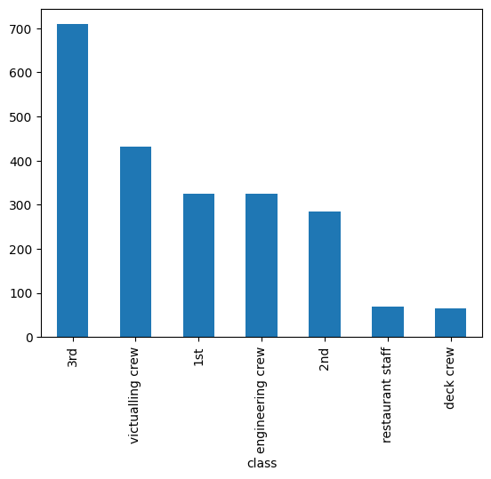

```python
df_titanic["class"].value_counts().plot(kind="bar")
```

This bar chart summarizes the class variable. I like that it shows the ordered counts of each category. However, it is missing a label for the y axis and a title.

2. Now click on the "generate" with AI link, or the Gemini button. Write a prompt to reproduce some of your analysis from earlier in this notebook. You can copy and paste one of the questions, or you can try writing your own prompt. Run the code and examine the results. How successful was it?

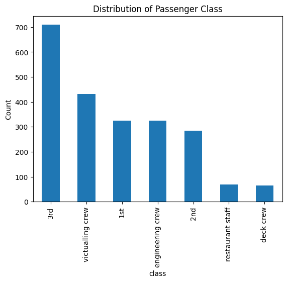

```python
import matplotlib.pyplot as plt
df_titanic["class"].value_counts().plot(kind="bar")
plt.ylabel("Count")
plt.title("Distribution of Passenger Class")
```

I told it to make a bar chart for the class variable. Initially, it just generated the same plot as mine, but after prompting it to "make it better", it added a label for the y axis and a title.